# Statistical learning and optimization of the helical milling of the biocompatible titanium Ti-6Al-7Nb alloy

Robson Bruno Dutra Pereira, Tomás Barbosa da Costa

2022-07-28

## Experimental Design and measurements

### Libraries used in the analysis

```r
library(rsm)
library(ggplot2)
library(GGally)
library(dplyr)
library(randomForest)
library(e1071)
library(ggpubr)
library(mco)
library(RColorBrewer)
```

### CCD and roughness results

Firstly the central composite design is defined and the roughness measurements are stored.

```r
plan2 <- ccd(~x1+x2+x3,
             n0 = c(0,4),
             alpha = "rotatable",
             randomize = FALSE,
             oneblock=TRUE,
             coding = list(x1 ~ (fza - .03)/.01,
                           x2 ~ (fzt - 3)/1,
                           x3 ~ (vc - 60)/10))

plan2$Ra <- c(0.1783333, 0.3041667, 0.1891667, 0.1450000, 0.1175000, 0.2900000, 0.2008333, 0.1700000, 0.1875000, 0.1966667, 0.3508333, 0.1083333, 0.1316667, 0.1575000, 0.1400000, 0.1241667, 0.1316667, 0.1216667)
plan2$Rq <- c(0.2208333, 0.3675000, 0.2391667, 0.1775000, 0.1450000, 0.3791667, 0.2500000, 0.2025000, 0.2166667, 0.2425000, 0.4225000, 0.1366667, 0.1650000, 0.1916667, 0.1700000, 0.1525000, 0.1641667, 0.1458333)
plan2$Rz <- c(0.9500000, 1.4916667, 1.0083333, 0.7833333, 0.6333333, 1.4583333, 1.0583333, 0.8583333, 1.0083333, 1.0083333, 1.6916667, 0.6166667, 0.7750000, 0.8000000, 0.7500000, 0.6500000, 0.7333333, 0.6500000)

plan2
```

```
##    run.order std.order        fza      fzt       vc        Ra        Rq
## 1          1         1 0.02000000 2.000000 50.00000 0.1783333 0.2208333
## 2          2         2 0.04000000 2.000000 50.00000 0.3041667 0.3675000
## 3          3         3 0.02000000 4.000000 50.00000 0.1891667 0.2391667
## 4          4         4 0.04000000 4.000000 50.00000 0.1450000 0.1775000
## 5          5         5 0.02000000 2.000000 70.00000 0.1175000 0.1450000
## 6          6         6 0.04000000 2.000000 70.00000 0.2900000 0.3791667
## 7          7         7 0.02000000 4.000000 70.00000 0.2008333 0.2500000
## 8          8         8 0.04000000 4.000000 70.00000 0.1700000 0.2025000
## 9          1         1 0.01318207 3.000000 60.00000 0.1875000 0.2166667
## 10         2         2 0.04681793 3.000000 60.00000 0.1966667 0.2425000
## 11         3         3 0.03000000 1.318207 60.00000 0.3508333 0.4225000
## 12         4         4 0.03000000 4.681793 60.00000 0.1083333 0.1366667
## 13         5         5 0.03000000 3.000000 43.18207 0.1316667 0.1650000
## 14         6         6 0.03000000 3.000000 76.81793 0.1575000 0.1916667
```

[output cut: 28 more lines]

### Principal component analysis

Some multivariate statistics and correlations are calculated.

```r
summary(plan2[,6:8]) # summary stats
```

```
##        Ra               Rq               Rz
##  Min.   :0.1083   Min.   :0.1367   Min.   :0.6167
##  1st Qu.:0.1317   1st Qu.:0.1644   1st Qu.:0.7375
##  Median :0.1638   Median :0.1971   Median :0.8292
##  Mean   :0.1803   Mean   :0.2216   Mean   :0.9403
##  3rd Qu.:0.1948   3rd Qu.:0.2417   3rd Qu.:1.0083
##  Max.   :0.3508   Max.   :0.4225   Max.   :1.6917
```

```r
colMeans(plan2[,6:8]) # mean vector
```

```
##        Ra        Rq        Rz
## 0.1802778 0.2216204 0.9402778
```

```r
var(plan2[,6:8]) # covariance matrix
```

```
##             Ra          Rq         Rz
## Ra 0.004777695 0.005880569 0.02171242
## Rq 0.005880569 0.007295219 0.02679119
## Rz 0.021712417 0.026791191 0.09939747
```

```r
r <- cor(plan2[,6:8]) # correlation matrix
r
```

```
##           Ra        Rq        Rz
## Ra 1.0000000 0.9960725 0.9963485
## Rq 0.9960725 1.0000000 0.9949132
## Rz 0.9963485 0.9949132 1.0000000
```

Visualization is also important to see the pattern of each variable and their relation.

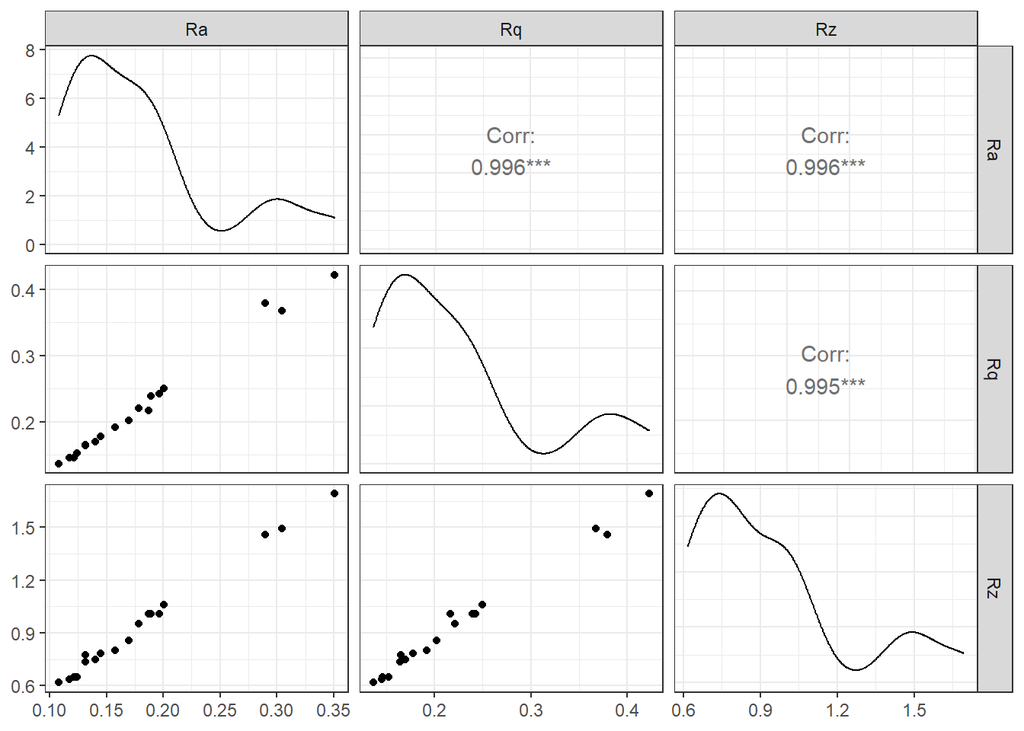

```r
ggpairs(plan2,
        columns = c(6:8)) + theme_bw()
```

Following PCA is performed for dimensionality reduction.

```r
pca_rug <- prcomp(plan2[,6:8], scale = TRUE)
pca_rug$sdev^2 # eigenvalues
```

```
## [1] 2.991556291 0.005101333 0.003342375
```

```r
pca_rug$rotation # eigenvectors
```

```
##          PC1         PC2        PC3
## Ra 0.5775174 -0.07423529 -0.8129962
## Rq 0.5772400  0.74134188  0.3423539
## Rz 0.5772934 -0.66700925  0.4709894
```

```r
pca_rug2 <- princomp(plan2[,6:8], cor = TRUE, scores = TRUE)
plan2$PC1 <- pca_rug2$scores[,1] # scores
```

## Learning process phase I

### Response surface regression

Firstly, a metrics function is defined.

```r
metrics <- function(pred, obs) {

  RSE <- sum((obs - pred)^2)
  SST <- sum((obs - mean(obs))^2)
  R2 <- 1 - RSE/SST

  MSE <-  mean((obs - pred)^2)

  RMSE <- sqrt(mean((obs - pred)^2))

  MAE <-  mean(abs(obs - pred))

  return(
    data.frame(RMSE = RMSE,
               MSE = MSE,
               R2 = R2,
               MAE = MAE))

}
```

RSM complete and reduced models are obtained through least squares considering the whole data. AIC is evaluated.

```r
comp1 <- lm(PC1 ~ x1 + x2 + x3 + x1*x2 + x1*x3 + x2*x3 + I(x1^2) + I(x2^2) + I(x3^2),
            data = plan2)
summary(comp1) # complete rsm model
```

```
##
## Call:
## lm(formula = PC1 ~ x1 + x2 + x3 + x1 * x2 + x1 * x3 + x2 * x3 +
##     I(x1^2) + I(x2^2) + I(x3^2), data = plan2)
##
## Residuals:
##      Min       1Q   Median       3Q      Max
## -1.31158 -0.33547  0.01335  0.35969  1.10907
##
## Coefficients:
##             Estimate Std. Error t value Pr(>|t|)
## (Intercept) -1.35016    0.46242  -2.920  0.01930 *
## x1           0.44068    0.25063   1.758  0.11675
## x2          -1.10515    0.25063  -4.410  0.00226 **
## x3          -0.01361    0.25063  -0.054  0.95801
## I(x1^2)      0.62099    0.26042   2.385  0.04423 *
## I(x2^2)      0.95506    0.26042   3.667  0.00633 **
## I(x3^2)      0.20349    0.26042   0.781  0.45707
## x1:x2       -1.24914    0.32746  -3.815  0.00513 **
## x1:x3        0.22548    0.32746   0.689  0.51057
## x2:x3        0.31881    0.32746   0.974  0.35879
## ---
## Signif. codes:  0 '***' 0.001 '**' 0.01 '*' 0.05 '.' 0.1 ' ' 1
##
## Residual standard error: 0.9262 on 8 degrees of freedom
## Multiple R-squared:  0.8726, Adjusted R-squared:  0.7292
## F-statistic: 6.086 on 9 and 8 DF,  p-value: 0.009125
```

```r
red_comp1 <- step(comp1)
```

```
## Start:  AIC=2.64
## PC1 ~ x1 + x2 + x3 + x1 * x2 + x1 * x3 + x2 * x3 + I(x1^2) +
##     I(x2^2) + I(x3^2)
##
##           Df Sum of Sq     RSS     AIC
## - x1:x3    1    0.4067  7.2695  1.6798
## - I(x3^2)  1    0.5238  7.3866  1.9673
## <none>                  6.8628  2.6434
## - x2:x3    1    0.8131  7.6759  2.6589
## - I(x1^2)  1    4.8779 11.7407 10.3084
## - I(x2^2)  1   11.5378 18.4006 18.3962
## - x1:x2    1   12.4827 19.3455 19.2976
##
## Step:  AIC=1.68
## PC1 ~ x1 + x2 + x3 + I(x1^2) + I(x2^2) + I(x3^2) + x1:x2 + x2:x3
##
##           Df Sum of Sq     RSS     AIC
## - I(x3^2)  1    0.5238  7.7933  0.9321
## - x2:x3    1    0.8131  8.0826  1.5882
## <none>                  7.2695  1.6798
## - I(x1^2)  1    4.8779 12.1474  8.9214
## - I(x2^2)  1   11.5378 18.8073 16.7898
## - x1:x2    1   12.4827 19.7523 17.6721
##
## Step:  AIC=0.93
## PC1 ~ x1 + x2 + x3 + I(x1^2) + I(x2^2) + x1:x2 + x2:x3
##
##           Df Sum of Sq     RSS     AIC
## - x2:x3    1    0.8131  8.6064  0.7185
## <none>                  7.7933  0.9321
## - I(x1^2)  1    4.4255 12.2188  7.0268
## - I(x2^2)  1   11.0142 18.8075 14.7899
## - x1:x2    1   12.4827 20.2760 16.1432
##
## Step:  AIC=0.72
## PC1 ~ x1 + x2 + x3 + I(x1^2) + I(x2^2) + x1:x2
##
##           Df Sum of Sq     RSS     AIC
## - x3       1    0.0025  8.6089 -1.2763
## <none>                  8.6064  0.7185
## - I(x1^2)  1    4.4255 13.0319  6.1865
## - I(x2^2)  1   11.0142 19.6206 13.5517
## - x1:x2    1   12.4827 21.0891 14.8509
##
## Step:  AIC=-1.28
## PC1 ~ x1 + x2 + I(x1^2) + I(x2^2) + x1:x2
##
##           Df Sum of Sq     RSS     AIC
## <none>                  8.6089 -1.2763
## - I(x1^2)  1    4.4255 13.0344  4.1900
## - I(x2^2)  1   11.0142 19.6231 11.5541
## - x1:x2    1   12.4827 21.0917 12.8531
```

```r
summary(red_comp1) # reduced rsm model
```

```
##
## Call:
## lm(formula = PC1 ~ x1 + x2 + I(x1^2) + I(x2^2) + x1:x2, data = plan2)
##
## Residuals:
##      Min       1Q   Median       3Q      Max
## -1.42595 -0.31910  0.03767  0.44505  1.17817
##
## Coefficients:
##             Estimate Std. Error t value Pr(>|t|)
## (Intercept)  -1.1311     0.3363  -3.363 0.005639 **
## x1            0.4407     0.2292   1.923 0.078572 .
## x2           -1.1052     0.2292  -4.822 0.000418 ***
## I(x1^2)       0.5784     0.2329   2.484 0.028764 *
## I(x2^2)       0.9124     0.2329   3.918 0.002042 **
## x1:x2        -1.2491     0.2995  -4.171 0.001296 **
## ---
## Signif. codes:  0 '***' 0.001 '**' 0.01 '*' 0.05 '.' 0.1 ' ' 1
##
## Residual standard error: 0.847 on 12 degrees of freedom
## Multiple R-squared:  0.8401, Adjusted R-squared:  0.7735
## F-statistic: 12.61 on 5 and 12 DF,  p-value: 0.0001963
```

Leave-one-out cross-validation is performed to compared the complete and reduced models. Box-blots are obtained to compare the models. Wilcoxon rank sum test is performed to compare the models.

```r
nr <- 1:nrow(plan2)
prop <- 1/18
nfolds <- round(1/prop,0)
fr <- round(prop*length(nr))

res.teste_PC1 <- data.frame(fold = numeric(2*nfolds),
                            method = character(2*nfolds),
                            RMSE = numeric(2*nfolds),
                            MSE = numeric(2*nfolds),
                            Rsquared = numeric(2*nfolds),
                            MAE = numeric(2*nfolds))

set.seed(2)

###
for (i in 1:nfolds) {

  fold <- sample(nr[!is.na(nr)], fr, replace = F)
  assign(paste0("fold", i),fold)
  nr[fold] <- NA
  plan.tr <- plan2[-fold,]

  comp_PC1 <- lm(PC1 ~ x1 + x2 + x3 + x1*x2 + x1*x3 + x2*x3 + I(x1^2) + I(x2^2) + I(x3^2),
                 data = plan.tr)

  red_PC1 <- lm(PC1 ~ x1 + x2 + x1*x2 + I(x1^2) + I(x2^2),
                data = plan.tr)

  assign(paste0("comp_PC1.", i), comp_PC1)
  assign(paste0("red_PC1.", i), red_PC1)

  res.teste.comp_PC1 <- predict(comp_PC1, newdata = plan2[fold,])

  res.teste.red_PC1 <- predict(red_PC1, newdata = plan2[fold,])

  testee.comp <- data.frame(obs = plan2$PC1[fold],
                           pred = res.teste.comp_PC1)
  testee.red <- data.frame(obs = plan2$PC1[fold],
                          pred = res.teste.red_PC1)

  res.teste.comp <- metrics(testee.comp$pred, testee.comp$obs)
  res.teste.red <- metrics(testee.red$pred, testee.red$obs)

  assign(paste0("res.teste.comp", i), (res.teste.comp))
  assign(paste0("res.teste.red", i), (res.teste.red))

  j <- (i-1)*2+1
  res.teste_PC1[j:(j+1),1] <- i
  res.teste_PC1[j:(j+1),2] <- c("comp", "red")
  res.teste_PC1[j,3:6]   <- (res.teste.comp)
  res.teste_PC1[j+1,3:6] <- (res.teste.red)

}

res.teste_PC1 %>%
  group_by(method) %>%
  summarise_at(vars(RMSE, MSE, MAE), list(name = mean))
```

```
## # A tibble: 2 × 4
##   method RMSE_name MSE_name MAE_name
##   <chr>      <dbl>    <dbl>    <dbl>
## 1 comp       1.23      2.49    1.23
## 2 red        0.854     1.57    0.854
```

```r
res.teste_PC1 %>%
  group_by(method) %>%
  summarise_at(vars(RMSE, MSE, MAE), list(name = median))
```

```
## # A tibble: 2 × 4
##   method RMSE_name MSE_name MAE_name
##   <chr>      <dbl>    <dbl>    <dbl>
## 1 comp       1.05     1.12     1.05
## 2 red        0.490    0.242    0.490
```

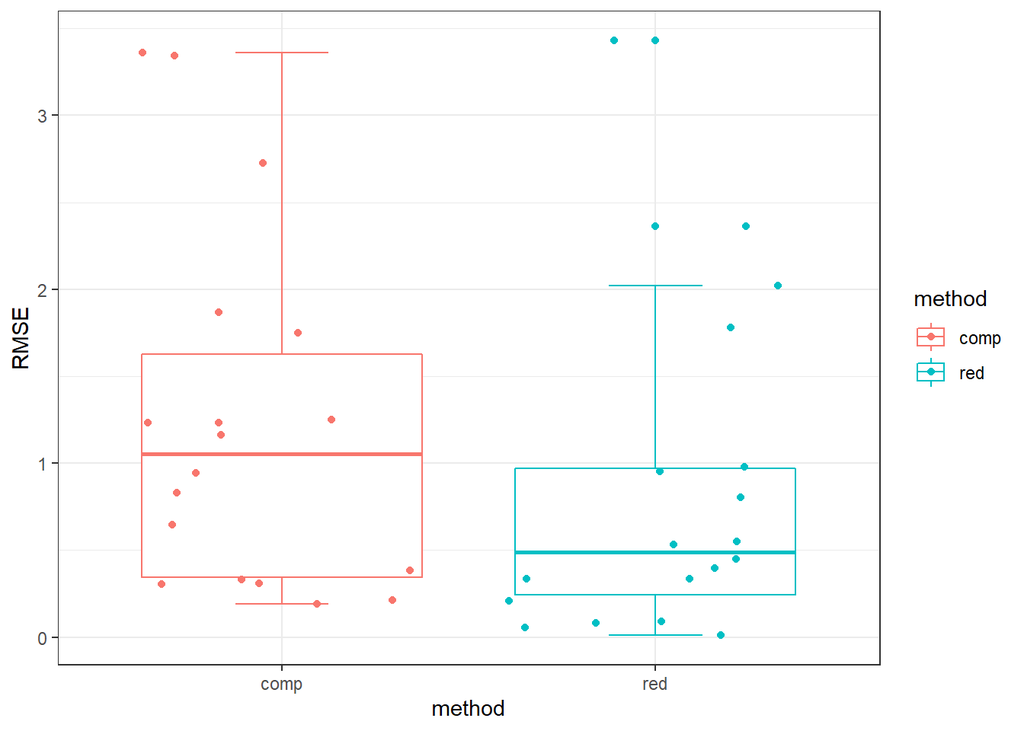

```r
library(ggplot2)
ggplot(res.teste_PC1, aes(x = method, y = RMSE, col = method)) +
  stat_boxplot(geom = "errorbar",
               width = 0.25) +
  geom_boxplot() + geom_jitter() + theme_bw()
```

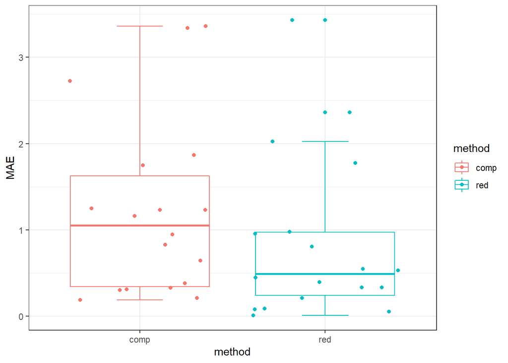

```r
ggplot(res.teste_PC1, aes(x = method, y = MAE, col = method)) +
  stat_boxplot(geom = "errorbar",
               width = 0.25) +
  geom_boxplot() + geom_jitter() + theme_bw()
```

```r
res <- wilcox.test(MSE ~ method, res.teste_PC1)
res
```

```
##
##  Wilcoxon rank sum test with continuity correction
##
## data:  MSE by method
## W = 202, p-value = 0.2113
## alternative hypothesis: true location shift is not equal to 0
```

### Tree based methods

Bagging and random forest are also compared through leave-one-out cross-validation.

```r
nr <- 1:nrow(plan2)
prop <- 1/18
nfolds <- round(1/prop,0)
fr <- round(prop*length(nr))

res.teste_PC1 <- data.frame(fold = numeric(2*nfolds),
                            method = character(2*nfolds),
                            RMSE = numeric(2*nfolds),
                            MSE = numeric(2*nfolds),
                            Rsquared = numeric(2*nfolds),
                            MAE = numeric(2*nfolds))

set.seed(2)
###
for (i in 1:nfolds) {

  fold <- sample(nr[!is.na(nr)], fr, replace = F)
  assign(paste0("fold", i),fold)
  nr[fold] <- NA

  plan.tr <- plan2[-fold,]

  # bagging
  bag_PC1 <- randomForest(PC1 ~ x1+x2+x3, data = plan.tr,
                          mtry = 3, importance = TRUE, ntree = 500)

  # random forest
  rf_PC1 <- randomForest(PC1 ~ x1+x2+x3, data = plan.tr,
                          mtry = 1, importance = TRUE, ntree = 500)

  res.teste.bag_PC1 <- predict(bag_PC1, newdata = plan2[fold,])
  res.teste.rf_PC1 <- predict(rf_PC1, newdata = plan2[fold,])

  testee.bag <- data.frame(obs = plan2$PC1[fold],
                           pred = res.teste.bag_PC1)
  testee.rf <- data.frame(obs = plan2$PC1[fold],
                           pred = res.teste.rf_PC1)

  res.teste.bag <- metrics(testee.bag$pred, testee.bag$obs)
  res.teste.rf <- metrics(testee.rf$pred, testee.rf$obs)

  j <- (i-1)*2+1
  res.teste_PC1[j:(j+1),1] <- i
  res.teste_PC1[j:(j+1),2] <- c("bag", "rf")
  res.teste_PC1[j,3:6]   <- (res.teste.bag)
  res.teste_PC1[j+1,3:6] <- (res.teste.rf)

}

res.teste_PC1 %>%
  group_by(method) %>%
  summarise_at(vars(RMSE, MSE, MAE), list(name = mean))
```

```
## # A tibble: 2 × 4
##   method RMSE_name MSE_name MAE_name
##   <chr>      <dbl>    <dbl>    <dbl>
## 1 bag         1.19     2.87     1.19
## 2 rf          1.29     3.01     1.29
```

```r
res.teste_PC1 %>%
  group_by(method) %>%
  summarise_at(vars(RMSE, MSE, MAE), list(name = median))
```

```
## # A tibble: 2 × 4
##   method RMSE_name MSE_name MAE_name
##   <chr>      <dbl>    <dbl>    <dbl>
## 1 bag        0.688    0.474    0.688
## 2 rf         0.909    0.828    0.909
```

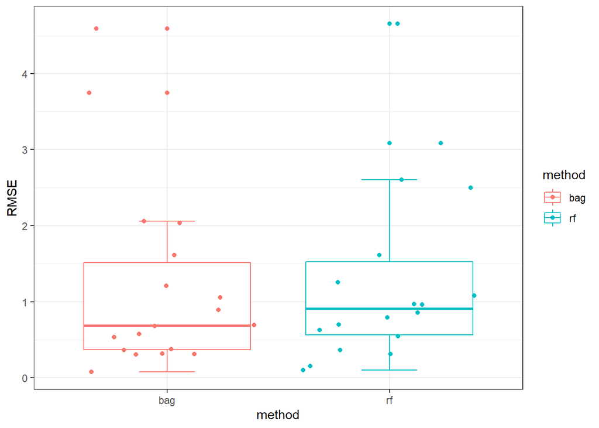

```r
ggplot(res.teste_PC1, aes(x = method, y = RMSE, col = method)) +
  stat_boxplot(geom = "errorbar",
               width = 0.25) +
  geom_boxplot() + geom_jitter() + theme_bw()
```

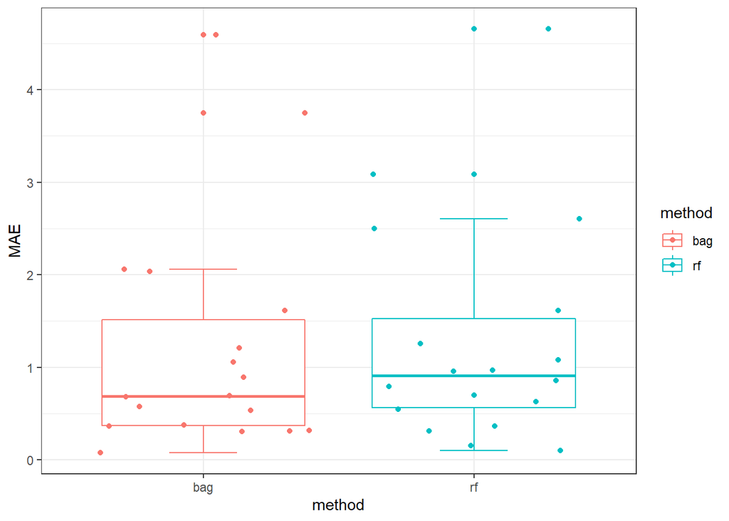

```r
ggplot(res.teste_PC1, aes(x = method, y = MAE, col = method)) +
  stat_boxplot(geom = "errorbar",
               width = 0.25) +
  geom_boxplot() + geom_jitter() + theme_bw()
```

```r
res <- wilcox.test(MSE ~ method, res.teste_PC1)
res
```

```
##
##  Wilcoxon rank sum exact test
##
## data:  MSE by method
## W = 143, p-value = 0.5628
## alternative hypothesis: true location shift is not equal to 0
```

### Support vector regression

SVR hyperparamters are defined through k-fold. The first k-fold is for kernel selection.

```r
set.seed(1)
tune.out <- tune(svm, PC1 ~ x1+x2+x3, data = plan2,
                 ranges = list(cost=c(0.001, 0.01, 0.1, 1, 5, 10),
                               gamma = c(0, 0.5, 1, 2),
                               kernel = c("linear", "radial", "polynomial")))
summary(tune.out)
```

```
##
## Parameter tuning of 'svm':
##
## - sampling method: 10-fold cross validation
##
## - best parameters:
##  cost gamma kernel
##     5   0.5 radial
##
## - best performance: 2.44875
##
## - Detailed performance results:
##     cost gamma     kernel     error dispersion
## 1  1e-03   0.0     linear  4.562144   7.421828
## 2  1e-02   0.0     linear  4.548485   7.214839
```

[output cut: 70 more lines]

The second k-fold is to select $C$ and $\gamma$.

```r
tune.out2 <- tune(svm, Ra ~ x1+x2+x3, data = plan2, kernel = "radial",
                  ranges = list(cost = seq(0.001, 10, by = 0.1),
                                gamma = seq(0, 2, by = 0.01)))
tune.out2$best.parameters
```

```
##       cost gamma
## 1775 7.401  0.17
```

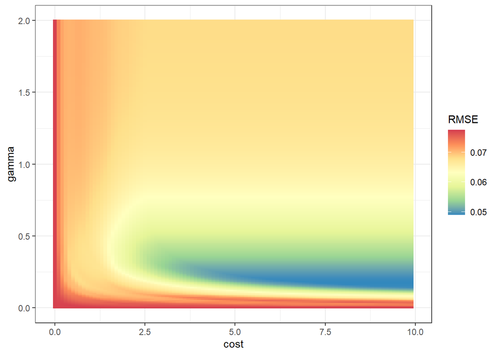

```r
tune_res <- data.frame(tune.out2$performances)

error_svm <- ggplot(data = tune_res,
                  mapping = aes(x = cost, y = gamma,
                                z = sqrt(error),
                                fill = sqrt(error))) +
  geom_tile() +
  labs(fill = "RMSE") +
  scale_fill_distiller(palette = "Spectral",
                       direction = -1) +
  # geom_contour(color = "gray50") +
  xlab("cost") + ylab("gamma") + theme_bw()
error_svm
```

## Learning process phase II

In the second phase of learning the models previously selected are compared. A bootstrap cross-validation with optimism corrected performance is performed.

```r
lm_ <- lm(PC1 ~ x1 + x2 + x1:x2 + I(x1^2) + I(x2^2), plan2)
bag_ <- randomForest(PC1 ~ x1+x2+x3, data = plan2,
                        mtry = 3, importance = TRUE, ntree = 500)
svm_ <- svm(PC1 ~ x1+x2+x3, data = plan2, kernel = "radial",
               cost = 9.901, gamma = 0.14)

### Apparent Performance
perf_lm  <- metrics(lm_$fitted.values, plan2$PC1)
perf_bag <- metrics(bag_$predicted, plan2$PC1)
perf_svm <- metrics(svm_$fitted, plan2$PC1)

perf_lm
perf_bag
perf_svm

nr <- 1:nrow(plan2)
B <- 200

res.teste_PC1 <- data.frame(fold = numeric(3*B),
                            method = character(3*B),
                            RMSE = numeric(3*B),
                            MSE = numeric(3*B),
                            Rsquared = numeric(3*B),
                            MAE = numeric(3*B))

optm_PC1 <- data.frame(fold = numeric(3*B),
                       method = character(3*B),
                       RMSE = numeric(3*B),
                       MSE = numeric(3*B),
                       Rsquared = numeric(3*B),
                       MAE = numeric(3*B))

set.seed(3)
###
for (i in 1:B) {
  ###
  fold <- sample(nr, length(nr), replace = T)
  plan.tr <- plan2[fold,]

  lm_PC1 <- lm(PC1 ~ x1 + x2 + x1:x2 + I(x1^2) + I(x2^2), plan.tr)
  bag_PC1 <- randomForest(PC1 ~ x1+x2+x3, data = plan.tr,
                          mtry = 3, importance = TRUE, ntree = 500)
  svm_PC1 <- svm(PC1 ~ x1+x2+x3, data = plan.tr, kernel = "radial",
                 cost = 9.901, gamma = 0.14)

  # Boot performance
  perf_boot_lm  <- metrics(lm_PC1$fitted.values, plan.tr$PC1)
  perf_boot_bag <- metrics(bag_PC1$predicted, plan.tr$PC1)
  perf_boot_svm <- metrics(svm_PC1$fitted, plan.tr$PC1)

  ###
  res.teste.lm_PC1 <- predict(lm_PC1, newdata = plan2)
  res.teste.bag_PC1 <- predict(bag_PC1, newdata = plan2)
  res.teste.svm_PC1 <- predict(svm_PC1, newdata = plan2)

  ###
  testee.rsm <- data.frame(obs = plan2$PC1,
                           pred = res.teste.lm_PC1)
  testee.bag <- data.frame(obs = plan2$PC1,
                           pred = res.teste.bag_PC1)
  testee.svm <- data.frame(obs = plan2$PC1,
                           pred = res.teste.svm_PC1)

  # Test performance
  res.teste.rsm <- metrics(testee.rsm$pred, testee.rsm$obs)
  res.teste.bag <- metrics(testee.bag$pred, testee.bag$obs)
  res.teste.svm <- metrics(testee.svm$pred, testee.svm$obs)

  ### Optimism
  optm_lm  <- perf_boot_lm  - res.teste.rsm
  optm_bag <- perf_boot_bag - res.teste.bag
  optm_svm <- perf_boot_svm - res.teste.svm

  ###
  j <- (i-1)*3+1
  res.teste_PC1[j:(j+2),1] <- i
  res.teste_PC1[j:(j+2),2] <- c("rsm", "bag", "svm")
  res.teste_PC1[j,3:6]   <- (res.teste.rsm)
  res.teste_PC1[j+1,3:6] <- (res.teste.bag)
  res.teste_PC1[j+2,3:6] <- (res.teste.svm)

  optm_PC1[j:(j+2),1] <- i
  optm_PC1[j:(j+2),2] <- c("rsm", "bag", "svm")

  optm_PC1[j,3:6]   <- (optm_lm)
  optm_PC1[j+1,3:6] <- (optm_bag)
  optm_PC1[j+2,3:6] <- (optm_svm)

}
```

[output not shown]

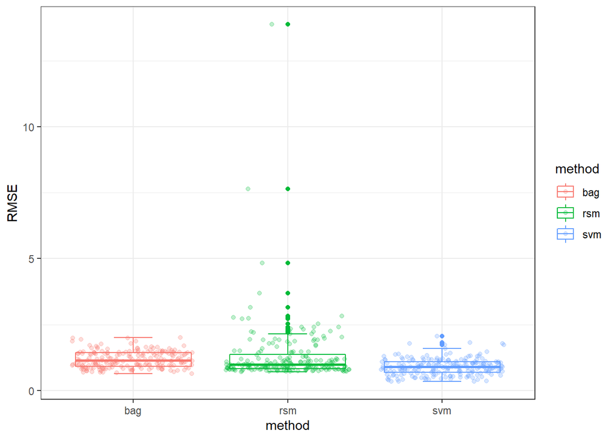

```r
###
boot_mean <- res.teste_PC1 %>%
  group_by(method) %>%
  summarise_at(vars(RMSE, MSE, Rsquared, MAE), list(name = mean))

boot_mean <- data.frame(boot_mean)
boot_mean

boot_median <- res.teste_PC1 %>%
  group_by(method) %>%
  summarise_at(vars(RMSE, MSE, Rsquared, MAE), list(name = median))

boot_median <- data.frame(boot_median)
boot_median

###
optm_mean <- optm_PC1 %>%
  group_by(method) %>%
  summarise_at(vars(RMSE, MSE, Rsquared, MAE), list(name = mean))

optm_mean <- data.frame(optm_mean)
optm_mean

optm_median <- optm_PC1 %>%
  group_by(method) %>%
  summarise_at(vars(RMSE, MSE, Rsquared, MAE), list(name = median))

optm_median <- data.frame(optm_median)
optm_median

# Optimism correctd performance
# mean
perf_lm - optm_mean[2,2:5]
### bag
perf_bag - optm_mean[1,2:5]
### svm
perf_svm - optm_mean[3,2:5]
### xgb
# perf_xgb - optm_mean[4,2:5]

# median
perf_lm - optm_median[2,2:5]
### bag
perf_bag - optm_median[1,2:5]
### svm
perf_svm - optm_median[3,2:5]

###
ggplot(res.teste_PC1, aes(x = method, y = RMSE, color = method)) +
  stat_boxplot(geom = "errorbar",
               width = 0.25) +
  geom_boxplot() + geom_jitter(alpha = 0.25) + theme_bw()
```

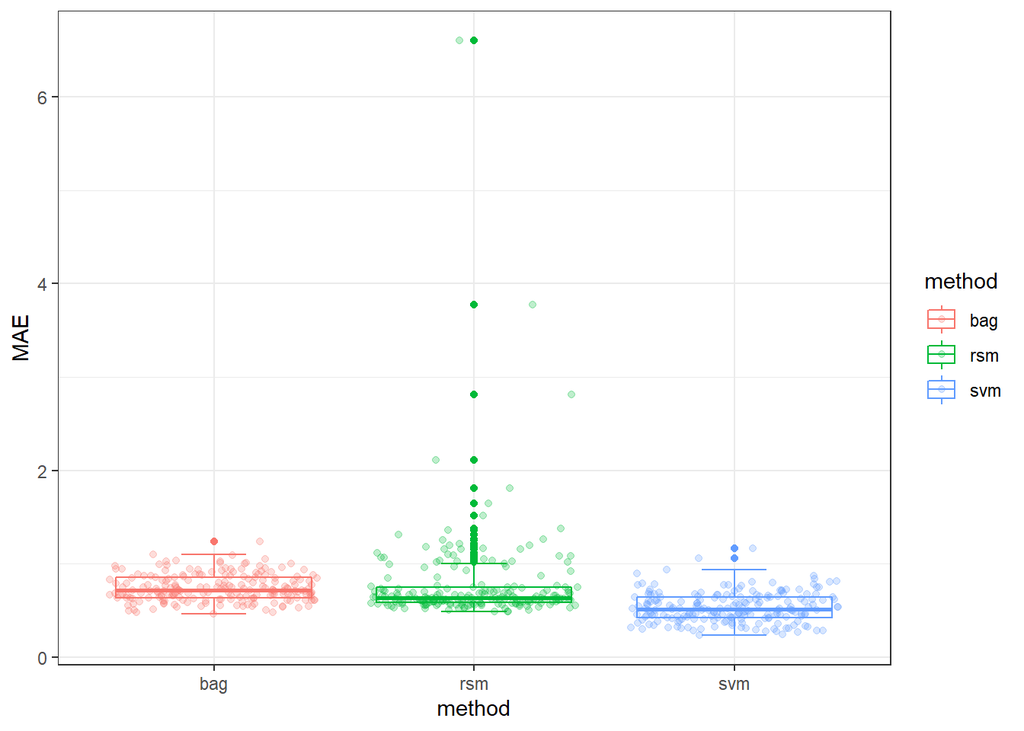

```r
ggplot(res.teste_PC1, aes(x = method, y = MAE, color = method)) +
  stat_boxplot(geom = "errorbar",
               width = 0.25) +
  geom_boxplot() + geom_jitter(alpha = 0.25) + theme_bw()
```

```r
###
kruskal.test(MSE ~ method, res.teste_PC1)
pairwise.wilcox.test(res.teste_PC1$MSE, res.teste_PC1$method,
                     p.adjust.method = "BH")
```

[output not shown]

## Model interpretation

SVR model effects and interactions are evaluated through plots.

```r
svm_PC1 <- svm(PC1 ~ x1+x2+x3, data = plan2, kernel = "radial",
               cost = 5.901, gamma = 0.2)
svm_PC1
```

```
##
## Call:
## svm(formula = PC1 ~ x1 + x2 + x3, data = plan2, kernel = "radial",
##     cost = 5.901, gamma = 0.2)
##
##
## Parameters:
##    SVM-Type:  eps-regression
##  SVM-Kernel:  radial
##        cost:  5.901
##       gamma:  0.2
##     epsilon:  0.1
##
##
## Number of Support Vectors:  17
```

```r
teste.svm_PC1 <- predict(svm_PC1, newdata = plan2)
metrics(teste.svm_PC1, plan2$PC1)
```

```
##        RMSE        MSE        R2       MAE
## 1 0.1861433 0.03464933 0.9884176 0.1839021
```

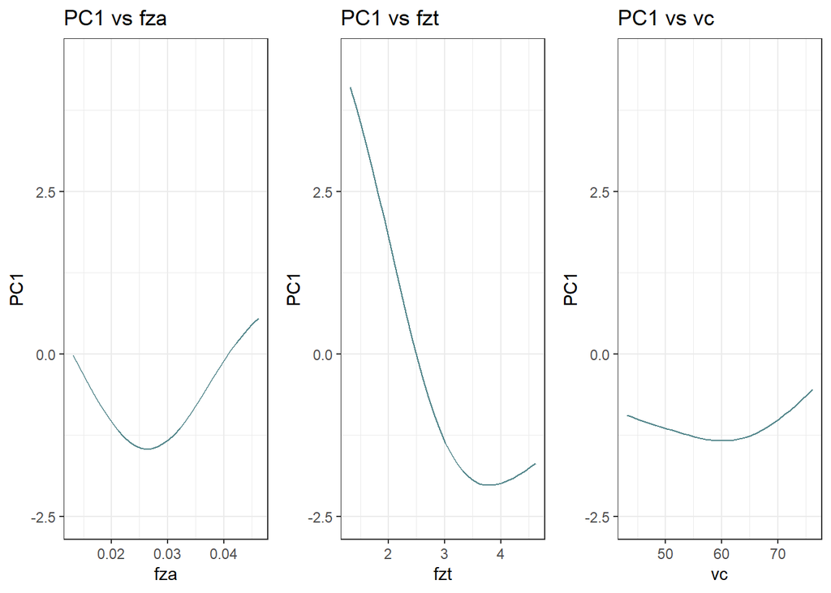

```r
###
x1_grid_pc1 <- seq(min(plan2$x1), max(plan2$x1), 0.1)

p1_pc1 <- ggplot() +
  geom_line(aes(x = x1_grid_pc1, y = (predict(svm_PC1,
                                              newdata = data.frame(x1 = x1_grid_pc1,
                                                                   x2 = 0,
                                                                   x3 = 0)))),
            colour = 'cadetblue4') +
  ggtitle('PC1 vs fza') +
  xlab('fza') +
  ylab('PC1') +
  ylim(-2.5,4.5) +
  scale_x_continuous(breaks = c(-1, 0, 1), label = c(0.02, 0.03, 0.04)) +
  theme_bw()

p2_pc1 <- ggplot() +
  geom_line(aes(x = x1_grid_pc1, y = (predict(svm_PC1,
                                              newdata = data.frame(x1 = 0,
                                                                   x2 = x1_grid_pc1,
                                                                   x3 = 0)))),
            colour = 'cadetblue4') +
  ggtitle('PC1 vs fzt') +
  xlab('fzt') +
  ylab('PC1') +
  ylim(-2.5,4.5) +
  scale_x_continuous(breaks = c(-1, 0, 1), label = c(2, 3, 4)) +
  theme_bw()

p3_pc1 <- ggplot() +
  geom_line(aes(x = x1_grid_pc1, y = (predict(svm_PC1,
                                              newdata = data.frame(x1 = 0,
                                                                   x2 = 0,
                                                                   x3 = x1_grid_pc1)))),
            colour = 'cadetblue4') +
  ggtitle('PC1 vs vc') +
  xlab('vc') +
  ylab('PC1') +
  ylim(-2.5,4.5) +
  scale_x_continuous(breaks = c(-1, 0, 1), label = c(50, 60, 70)) +
  theme_bw()
ggarrange(p1_pc1, p2_pc1, p3_pc1, nrow = 1)
```

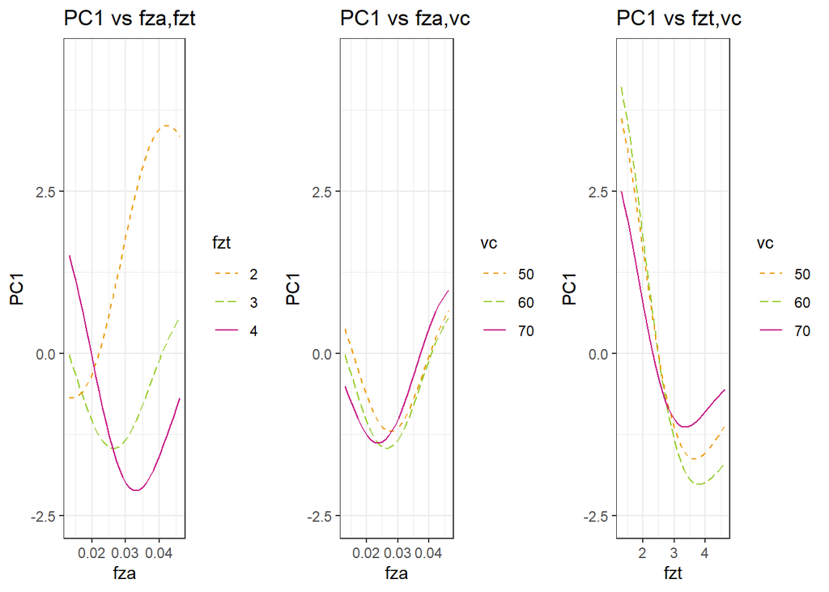

```r
###
pp_12a_pc1 <- ggplot() +
  geom_line(aes(x = x1_grid_pc1, y = (predict(svm_PC1, newdata = data.frame(x1 = x1_grid_pc1,
                                                                            x2 = 0,
                                                                            x3 = 0))),
                colour = '3', linetype = '3')) +
  ggtitle('PC1 vs fza,fzt') +
  xlab('fza') +
  ylab('PC1') +
  ylim(-2.5,4.5) +
  scale_x_continuous(breaks = c(-1, 0, 1), label = c(0.02, 0.03, 0.04)) +
  theme_bw()

pp_12_pc1 <- pp_12a_pc1 +
  geom_line(aes(x = x1_grid_pc1, y = (predict(svm_PC1, newdata = data.frame(x1 = x1_grid_pc1,
                                                                            x2 = -1,
                                                                            x3 = 0))),
                colour = '2', linetype = '2')) +
  geom_line(aes(x = x1_grid_pc1, y = (predict(svm_PC1, newdata = data.frame(x1 = x1_grid_pc1,
                                                                            x2 = 1,
                                                                            x3 = 0))),
                colour = '4', linetype = '4')) +
  scale_color_manual(name = "fzt",
                     values = c("2" = "orange2",
                                "3" = "olivedrab3",
                                "4" = "mediumvioletred")) +
  scale_linetype_manual(name = "fzt",
                        values = c("2" = "dashed",
                                   "3" = "longdash",
                                   "4" = "solid"))

pp_13a_pc1 <- ggplot() +
  geom_line(aes(x = x1_grid_pc1, y = (predict(svm_PC1, newdata = data.frame(x1 = x1_grid_pc1,
                                                                            x2 = 0,
                                                                            x3 = 0))),
                colour = '60', linetype = '60')) +
  ggtitle('PC1 vs fza,vc') +
  xlab('fza') +
  ylab('PC1') +
  ylim(-2.5,4.5) +
  scale_x_continuous(breaks = c(-1, 0, 1), label = c(0.02, 0.03, 0.04)) +
  theme_bw()

pp_13_pc1 <- pp_13a_pc1 +
  geom_line(aes(x = x1_grid_pc1, y = (predict(svm_PC1,
                                              newdata = data.frame(x1 = x1_grid_pc1,
                                                                   x2 = 0,
                                                                   x3 = -1))),
                colour = '50', linetype = '50')) +
  geom_line(aes(x = x1_grid_pc1, y = (predict(svm_PC1,
                                              newdata = data.frame(x1 = x1_grid_pc1,
                                                                   x2 = 0,
                                                                   x3 = 1))),
                colour = '70', linetype = '70')) +
  scale_color_manual(name = "vc",
                     values = c("50" = "orange2",
                                "60" = "olivedrab3",
                                "70" = "mediumvioletred")) +
  scale_linetype_manual(name = "vc",
                        values = c("50" = "dashed",
                                   "60" = "longdash",
                                   "70" = "solid"))

pp_23a_pc1 <- ggplot() +
  geom_line(aes(x = x1_grid_pc1, y = (predict(svm_PC1, newdata = data.frame(x1 = 0,
                                                                            x2 = x1_grid_pc1,
                                                                            x3 = 0))),
                colour = '60', linetype = '60')) +
  ggtitle('PC1 vs fzt,vc') +
  xlab('fzt') +
  ylab('PC1') +
  ylim(-2.5,4.5) +
  scale_x_continuous(breaks = c(-1, 0, 1), label = c(2, 3, 4)) +
  theme_bw()

pp_23_pc1 <- pp_23a_pc1 +
  geom_line(aes(x = x1_grid_pc1, y = (predict(svm_PC1,
                                              newdata = data.frame(x1 = 0,
                                                                   x2 = x1_grid_pc1,
                                                                   x3 = -1))),
                colour = '50', linetype = '50')) +
  geom_line(aes(x = x1_grid_pc1, y = (predict(svm_PC1,
                                              newdata = data.frame(x1 = 0,
                                                                   x2 = x1_grid_pc1,
                                                                   x3 = 1))),
                colour = '70', linetype = '70')) +
  scale_color_manual(name = "vc",
                     values = c("50" = "orange2",
                                "60" = "olivedrab3",
                                "70" = "mediumvioletred")) +
  scale_linetype_manual(name = "vc",
                        values = c("50" = "dashed",
                                   "60" = "longdash",
                                   "70" = "solid"))

ggarrange(pp_12_pc1, pp_13_pc1, pp_23_pc1, nrow = 1)
```

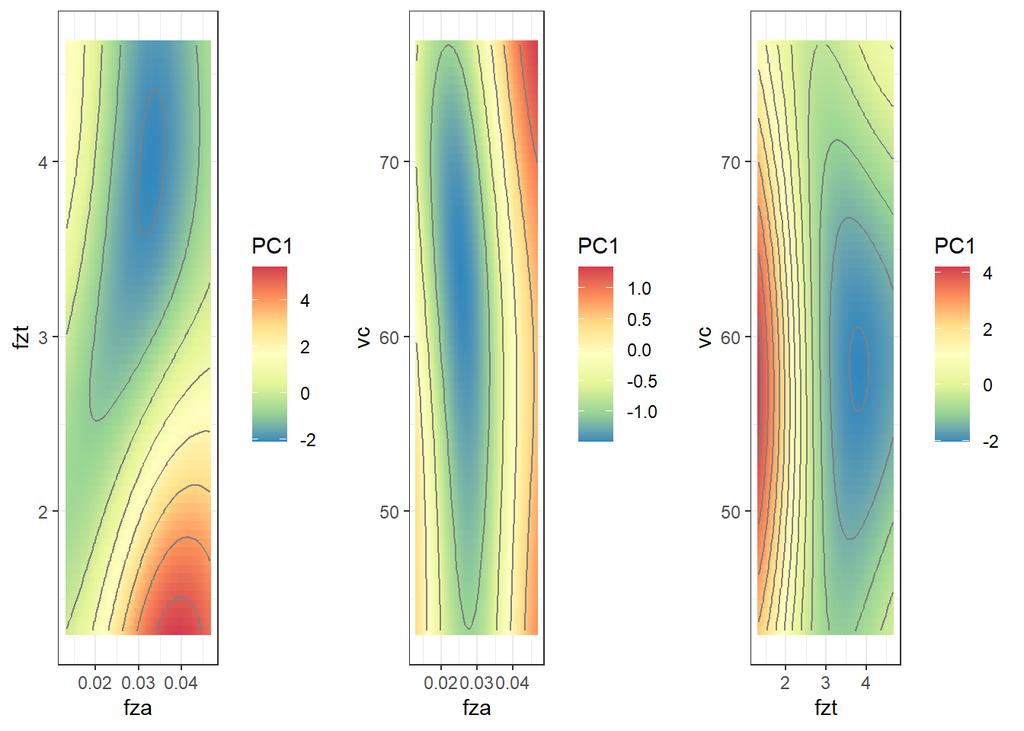

```r
###
x1grid_pc1 <- seq(min(plan2$x1), max(plan2$x1), 0.05)

grid_pc1 <- expand.grid(x1 = x1grid_pc1,
                        x2 = x1grid_pc1,
                        x3 = 0)

y_hat_pc1 <- predict(svm_PC1, newdata = grid_pc1)
grid_pc1$PC1 <- y_hat_pc1

cp1_pc1 <- ggplot(data = grid_pc1,
                  mapping = aes(x = x1, y = x2, z = PC1, fill = PC1)) +
  geom_tile() +
  scale_fill_distiller(palette = "Spectral",
                       direction = -1) +
  geom_contour(color = "gray50") +
  scale_x_continuous(breaks = c(-1, 0, 1), label = c(0.02, 0.03, 0.04)) +
  scale_y_continuous(breaks = c(-1, 0, 1), label = c(2,3,4)) +
  xlab("fza") + ylab("fzt") + theme_bw()

grid_pc1 <- expand.grid(x1 = x1grid_pc1,
                        x2 = 0,
                        x3 = x1grid_pc1)

y_hat_pc1 <- predict(svm_PC1, newdata = grid_pc1)
grid_pc1$PC1 <- y_hat_pc1

cp2_pc1 <- ggplot(data = grid_pc1,
                  mapping = aes(x = x1, y = x3, z = PC1, fill = PC1)) +
  geom_tile() +
  scale_fill_distiller(palette = "Spectral",
                       direction = -1) +
  geom_contour(color = "gray50") +
  scale_x_continuous(breaks = c(-1, 0, 1), label = c(0.02, 0.03, 0.04)) +
  scale_y_continuous(breaks = c(-1, 0, 1), label = c(50,60,70)) +
  xlab("fza") + ylab("vc") + theme_bw()

grid_pc1 <- expand.grid(x1 = 0,
                        x2 = x1grid_pc1,
                        x3 = x1grid_pc1)

y_hat_pc1 <- predict(svm_PC1, newdata = grid_pc1)
grid_pc1$PC1 <- y_hat_pc1

cp3_pc1 <- ggplot(data = grid_pc1,
                  mapping = aes(x = x2, y = x3, z = PC1, fill = PC1)) +
  geom_tile() +
  scale_fill_distiller(palette = "Spectral",
                       direction = -1) +
  geom_contour(color = "gray50") +
  scale_x_continuous(breaks = c(-1, 0, 1), label = c(2,3,4)) +
  scale_y_continuous(breaks = c(-1, 0, 1), label = c(50,60,70)) +
  xlab("fzt") + ylab("vc") + theme_bw()

ggarrange(cp1_pc1, cp2_pc1, cp3_pc1, nrow = 1)
```

## Multi-objective evolutionary optimization

Multi-objective evolutionary optimization is performed through NSGA-II algorithm.

```r
ro <- (2^3)^0.25

gg <- function(x){
  g1 <- -x[1]^2 - x[2]^2 -x[3]^2 + ro^2
  return(c(g1))
}

###
PC1_MRR <- function(x){


  # f^_svr/PC1
  f1 <- predict(svm_PC1, newdata = data.frame(x1 = x[1],
                                              x2 = x[2],
                                              x3 = x[3]))

  z <- 4
  Db <- 5
  Dt <- 3
  Dh <- Db-Dt

  fza <- x[1]*(0.04-0.02)/2 + 0.03
  fzt <- x[2]*(0.004-0.002)/2 + 0.003
  vc <-  x[3]*(70-50)/2 + 60

  # MRR
  f2 <- -250*z*(Db^3/(Dh*Dt))*vc*((fza*10^-3)/fzt)*sqrt((fza*10^-3)^2 + (fzt*Dh/Db)^2)

  return(c(f1,f2))
}

###
opt2_pc1 <- nsga2(fn = PC1_MRR,
                  idim = 3,
                  odim = 2,
                  constraints = gg,
                  cdim = 1,
                  lower.bounds = rep(-ro,3),
                  upper.bounds = rep(ro,3),
                  popsize = 200, generations = 100)

sol_opt2_pc1 <- opt2_pc1$value
colnames(sol_opt2_pc1) <- c("PC1", "MRR")
sol_opt2_pc1[,2] <- -sol_opt2_pc1[,2]
niveis_opt2_pc1 <- opt2_pc1$par
# write.csv(niveis_opt2_pc1, file = "niveis_opt2_pc1_svm.csv")
colnames(niveis_opt2_pc1) <- c("fza", "fzt", "vc") # nomes das colunas

niveis_opt2_pc1_decod <- data.frame(fza = niveis_opt2_pc1[,1]*(0.04-0.02)/2 + 0.03,
                                    fzt = niveis_opt2_pc1[,2]*(4-2)/2 + 3,
                                    vc = niveis_opt2_pc1[,3]*(70-50)/2 + 60)
head(niveis_opt2_pc1_decod)
```

```
##          fza      fzt       vc
## 1 0.03286661 3.967116 58.12613
## 2 0.04402874 2.956888 69.25304
## 3 0.04443815 3.197396 68.38668
## 4 0.04443815 3.220080 68.19985
## 5 0.04443815 3.113761 68.38668
## 6 0.04452038 3.290253 67.91391
```

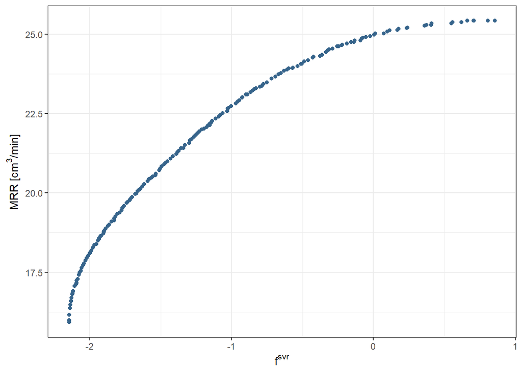

```r
###
ggplot(data.frame(sol_opt2_pc1), aes(x = PC1, y = MRR)) +
  geom_point(color = "steelblue4") +
  xlab(expression(paste("f"^"svr"))) +
  ylab(expression(paste("MRR [cm"^"3","/min]"))) +
  theme_bw()
```

The results are also studied in the design space.

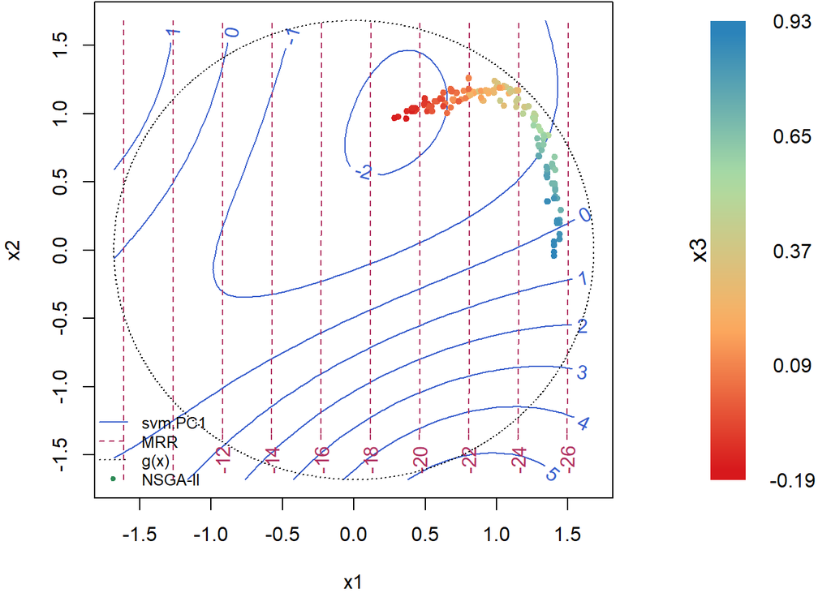

```r
niveis_maxmrr <- niveis_opt2_pc1[which.max(sol_opt2_pc1[,1]),]
niveis_minpc1 <- niveis_opt2_pc1[which.min(sol_opt2_pc1[,2]),]

niveis_maxmrr_decod <- niveis_opt2_pc1_decod[which.max(sol_opt2_pc1[,1]),]
niveis_minpc1_decod <- niveis_opt2_pc1_decod[which.min(sol_opt2_pc1[,2]),]

###
x1 <- seq(-1.681793,1.681793, length = 60) # x1 = fza coded
x2 <- seq(-1.681793,1.681793, length = 60) # x2 = fzt coded
x3 <- niveis_minpc1[3]
xys <- expand.grid(x1,x2,x3)
colnames(xys) <- c("x1", "x2", "x3")
zs <- matrix(predict(svm_PC1, newdata = xys), nrow = length(x1)) # previsao modelo PC1

MRR2 <- function(x1,x2,x3){

  z <- 4
  Db <- 5
  Dt <- 3
  Dh <- Db-Dt

  fza <- x1*(0.04-0.02)/2 + 0.03
  fzt <- x2*(0.004-0.002)/2 + 0.003
  vc <-  x3*(70-50)/2 + 60

  f2 <- -250*z*(Db^3/(Dh*Dt))*vc*((fza*10^-3)/fzt)*sqrt((fza*10^-3)^2 + (fzt*Dh/Db)^2)

  return(f2)
}

zs2 <- matrix((MRR2(xys[,1],xys[,2],niveis_maxmrr[3])), nrow = length(x1))

par(mfrow = c(1,1), mar = c(4, 4, 0.1, 0.1))
layout(matrix(1:2,ncol=2), width = c(2,.7),height = c(.7,2))
contour(x=x1, y=x2, z=zs, col = "royalblue3", #  "#C71585",
        labcex = 1, method = "edge",
        xlab = "x1", ylab = "x2")

contour(x=x1, y=x2, z=zs2, col = "maroon", # "#15C757",
        labcex = 1, add = T, lty = 2)

gx <- function(x) {
  y = sqrt(sqrt(2^3) - x^2)
  return(cbind(-y,y))
}

x_g <- seq(-(2^3)^.5, (2^3)^0.5, length = 100000)
lines(x_g, gx(x_g)[,1], col = "black", lty = 3)
lines(x_g, gx(x_g)[,2], col = "black", lty = 3)
x_nsga2 <- niveis_opt2_pc1
colnames(x_nsga2)<- c("x1","x2", "x3")

legend("bottomleft",
       legend = c("svm.PC1", "MRR", "g(x)", "NSGA-II"),
       lty = c(c(1,2,3),NA,NA),
       pch = c(rep(NA,3), 20, 19),
       col = c("royalblue3", "maroon", "black", "seagreen"),
       cex = .8, box.col = NA, bg="transparent")

cols = brewer.pal(4, "Spectral")
pal = colorRampPalette(cols)
vc = findInterval(x_nsga2[,3], sort(x_nsga2[,3]))
points(x_nsga2[,1:2], col = pal(nrow(x_nsga2))[vc], pch = 20)

colfunc <- colorRampPalette(c("#2B83BA", "#ABDDA4", "#FDAE61", "#D7191C"))
legend_image <-  as.raster(matrix(colfunc(20), ncol = 1))
plot(c(0.5,4), c(0,1), type = "n", axes = F, ylab = "", xlab = "")
title(ylab="x3", line=0, cex.lab=1.2)
lab <- round(seq(min(x_nsga2[,3]), max(x_nsga2[,3]), l = 5), 2)
text(x = 3, y = seq(0, 1, l = 5), labels = lab, cex = 1)
rasterImage(legend_image, -1,0,1.5,1)
```

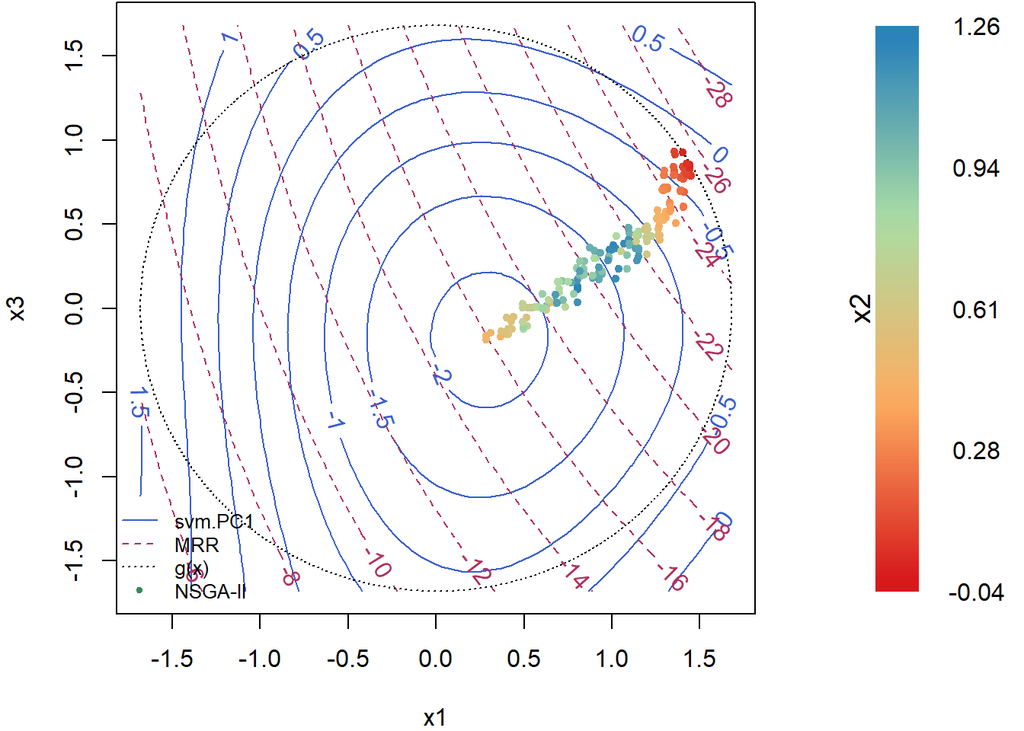

```r
###
x1 <- seq(-1.681793,1.681793, length = 60) # x1 = fza coded
x3 <- seq(-1.681793,1.681793, length = 60) # x2 = fzt coded
x2 <- niveis_minpc1[2]
xys <- expand.grid(x1,x2,x3)
colnames(xys) <- c("x1", "x2", "x3")
zs <- matrix(predict(svm_PC1, newdata = xys), nrow = length(x1))

zs2 <- matrix((MRR2(xys[,1],niveis_maxmrr[2],xys[,3])), nrow = length(x1))

par(mfrow = c(1,1), mar = c(4, 4, 0.1, 0.1))
layout(matrix(1:2,ncol=2), width = c(2,.7),height = c(.7,2))
contour(x=x1, y=x3, z=zs, col = "royalblue3", #  "#C71585",
        labcex = 1, method = "edge",
        xlab = "x1", ylab = "x3")

contour(x=x1, y=x3, z=zs2, col = "maroon", # "#15C757",
        labcex = 1, add = T, lty = 2)

lines(x_g, gx(x_g)[,1], col = "black", lty = 3)
lines(x_g, gx(x_g)[,2], col = "black", lty = 3)
legend("bottomleft",
       legend = c("svm.PC1", "MRR", "g(x)", "NSGA-II"),
       lty = c(c(1,2,3),NA,NA),
       pch = c(rep(NA,3), 20, 19),
       col = c("royalblue3", "maroon", "black", "seagreen"),
       cex = .8, box.col = NA, bg="transparent")

cols = brewer.pal(4, "Spectral")
pal = colorRampPalette(cols)
fzt = findInterval(x_nsga2[,2], sort(x_nsga2[,2]))
points(x_nsga2[,c(1,3)], col = pal(nrow(x_nsga2))[fzt], pch = 20)

colfunc <- colorRampPalette(c("#2B83BA", "#ABDDA4", "#FDAE61", "#D7191C"))
legend_image <-  as.raster(matrix(colfunc(20), ncol = 1))
plot(c(0.5,4), c(0,1), type = "n", axes = F, ylab = "", xlab = "")
title(ylab="x2", line=0, cex.lab=1.2)
lab <- round(seq(min(x_nsga2[,2]), max(x_nsga2[,2]), l = 5), 2)
text(x = 3, y = seq(0, 1, l = 5), labels = lab, cex = 1)
rasterImage(legend_image, -1,0,1.5,1)
```

Finally, some discussion on extreme and knee points is done.

```r
Db <- 5     # hole diameter
Dt <- 3     # tool diameter
Dh <- Db-Dt # helix diameter
z  <- 4     # number of teeth

### Min_PC1
ap_minpc1 <- niveis_minpc1_decod[1]*10^-3*pi*Db/(niveis_minpc1_decod[2]*10^-3)
ap_minpc1
```

```
##         fza
## 1 0.1301367
```

```r
n_minpc1 <- 1000*niveis_minpc1_decod[3]/(pi*Dt)
n_minpc1
```

```
##         vc
## 1 6167.374
```

```r
vfha_minpc1 <- niveis_minpc1_decod[1]*10^-3*z*n_minpc1
vfht_minpc1 <- niveis_minpc1_decod[2]*10^-3*z*n_minpc1*Dh/Db
vf_minpc1 <- sqrt(vfha_minpc1^2 + vfht_minpc1^2)
vf_minpc1
```

```
##        fza
## 1 39.15509
```

```r
### Max MRR
ap_maxmrr <- niveis_maxmrr_decod[1]*10^-3*pi*Db/(niveis_maxmrr_decod[2]*10^-3)
ap_maxmrr
```

```
##         fza
## 2 0.2338952
```

```r
n_maxmrr <- 1000*niveis_maxmrr_decod[3]/(pi*Dt)
n_maxmrr
```

```
##         vc
## 2 7347.975
```

```r
vfha_maxmrr <- niveis_maxmrr_decod[1]*10^-3*z*n_maxmrr
vfht_maxmrr <- niveis_maxmrr_decod[2]*10^-3*z*n_maxmrr*Dh/Db
vf_maxmrr <- sqrt(vfha_maxmrr^2 + vfht_maxmrr^2)
vf_maxmrr
```

```
##       fza
## 2 34.7875
```

```r
### knee
sol_norm_pc1 <- (sol_opt2_pc1[,1] - min(sol_opt2_pc1[,1]))/
  (max(sol_opt2_pc1[,1]) - min(sol_opt2_pc1[,1]))
sol_norm_mrr <- (-sol_opt2_pc1[,2] - min(-sol_opt2_pc1[,2]))/
  (max(-sol_opt2_pc1[,2]) - min(-sol_opt2_pc1[,2]))
sol_norm <- data.frame(sol_norm_pc1, sol_norm_mrr)

Dist <- numeric(200)
Dist <- apply(sol_norm, 1, function(x) sqrt(x[1]^2 + x[2]^2))
head(sol_norm)
```

```
##   sol_norm_pc1 sol_norm_mrr
## 1    0.0000000  1.000000000
## 2    1.0000000  0.000000000
## 3    0.8517051  0.009141008
## 4    0.8348833  0.016448361
## 5    0.8977280  0.009053492
## 6    0.7946181  0.022758334
```

```r
niveisknee <- niveis_opt2_pc1_decod[which.min(Dist),]
ap_knee <- niveisknee[1]*10^-3*pi*Db/(niveisknee[2]*10^-3)
ap_knee
```

```
##          fza
## 191 0.163774
```

```r
n_knee <- 1000*niveisknee[3]/(pi*Dt)
n_knee
```

```
##           vc
## 191 6821.487
```

```r
vfha_knee <- niveisknee[1]*10^-3*z*n_knee
vfht_knee <- niveisknee[2]*10^-3*z*n_knee*Dh/Db
vf_knee <- sqrt(vfha_knee^2 + vfht_knee^2)
vf_knee
```

```
##          fza
## 191 44.27452
```